# Estimating uncertainty

S&DS 220

Week 10, Day 2

```r
d = read.csv('NewHavenHousing.csv')

## remove houses over $500k, 5000 sq ft, and 10 acres
d = d[d$living<=5000 & d$value<=500000 & d$land<=10,]
d = d %>% filter(living<=5000, value<=500000, land<=10) ## same

m1 = lm(value ~ living, data=d)
d$yhat = predict(m1, newdata=d)
```

We have discussed how to form a simple linear regression model, how to find $\hat{\beta_0}$ and $\hat{\beta_1}$, and how to assess how much variance in $y$ is explained by the model using $R^2$. We now discuss another important topic: uncertainty in the estimates. How sure our we about the coefficients that we got from our model? If we get a value of 0.08 for $\hat{\beta_1}$, can we be confident that the true value is close to 0.08, say between 0.07 and 0.09, or can we only be confident that it is between 0.02 and 0.14? We would like to have a systematic way of understanding and communicating the uncertainty.

There are two kinds of uncertainty that we will discuss:

1. Uncertainty in our coefficients, both $\hat{\beta_0}$ and $\hat{\beta_1}$, the slope and intercept in our regression model.
2. Uncertainty in our predictions, both $\hat{y}$, our prediction for the expected value of $y$ given $x$ that we get from our regression model, and also any individual $y$.

These will require us knowing/estimating $\sigma^2$, so we’ll discuss that first.

## Estimate of the variance of the random error

Recall that one of our model assumptions is that the error term $\epsilon$ is normally distributed with mean 0 and variable $\sigma^2$. The true value of $\sigma^2$ is typically unknown, but we can estimate $\sigma^2$ using

$$s^2 = \hat{\sigma}^2 = \frac{SSE}{n-2}$$

where $n$ is the number of observations in our data (the number of rows in our data set). The square root of $\hat{\sigma}^2$ is the residual standard deviation. In our case we have

```r
sse = sum((d$value - d$yhat)^2)
s2 = sse/(nrow(d)-2)
s2
```

```
[1] 1927356131
```

```r
s=sqrt(s2)
s
```

```
[1] 43901.66
```

Since the residuals are automatically computed by the `lm` function, and can be found in `m1$residuals` the quantities $\hat{\sigma}^2$ and $\hat{\sigma}$ can also be found in the following way

```r
s2 = sum(m1$residuals^2)/(nrow(d)-2)
s = sqrt(s2)
s
```

```
[1] 43901.66
```

Note that output of `summary(m1)` contains “Residual standard error: 43901.66”.

```r
summary(m1)
```

```
Call:
lm(formula = value ~ living, data = d)

Residuals:
    Min      1Q  Median      3Q     Max
-272751  -23631   -2769   16182  272332

Coefficients:
              Estimate Std. Error t value Pr(>|t|)
(Intercept) -8089.6005  1280.9929  -6.315 2.83e-10 ***
living         89.1210     0.7364 121.024  < 2e-16 ***
---
Signif. codes:  0 '***' 0.001 '**' 0.01 '*' 0.05 '.' 0.1 ' ' 1

Residual standard error: 43900 on 8900 degrees of freedom
Multiple R-squared:  0.622, Adjusted R-squared:  0.622
F-statistic: 1.465e+04 on 1 and 8900 DF,  p-value: < 2.2e-16
```

This can also be found directly by

```r
summary(m1)$sigma
```

```
[1] 43901.66
```

Not sure why "Residual standard error in the summary and `summary(m1)$sigma` don’t match exactly, but I think it is because of rounding. It should be the same:

```r
m2 = lm(mpg~wt, data=mtcars)
summary(m2)
```

```
Call:
lm(formula = mpg ~ wt, data = mtcars)

Residuals:
    Min      1Q  Median      3Q     Max
-4.5432 -2.3647 -0.1252  1.4096  6.8727

Coefficients:
            Estimate Std. Error t value Pr(>|t|)
(Intercept)  37.2851     1.8776  19.858  < 2e-16 ***
wt           -5.3445     0.5591  -9.559 1.29e-10 ***
---
Signif. codes:  0 '***' 0.001 '**' 0.01 '*' 0.05 '.' 0.1 ' ' 1

Residual standard error: 3.046 on 30 degrees of freedom
Multiple R-squared:  0.7528,    Adjusted R-squared:  0.7446
F-statistic: 91.38 on 1 and 30 DF,  p-value: 1.294e-10
```

```r
summary(m2)$sigma
```

```
[1] 3.045882
```

```r
sigma(m2)
```

```
[1] 3.045882
```

## Sampling Distribution of $\hat{\beta_1}$

Since $\hat{\beta_1}$ is a statistic, it has a sampling distribution. It can be shown that

1. $E(\hat{\beta_1}) = \beta_1$
2. $V(\hat{\beta_1}) = \frac{\sigma^2}{S_{xx}}$
3. $\hat{\beta_1}$ is normal

Since $\sigma^2$ is unknown, it is estimated by $s^2$, and $V(\hat{\beta_1})$ can be estimated with $s^2_{\hat{\beta_1}} = \frac{s^2}{S_{xx}}$.

```r
sxx = sum((d$living - mean(d$living))^2)
s2beta1 = s2/sxx
sbeta1 = sqrt(s2beta1)
sbeta1
```

```
[1] 0.7363912
```

Note the summary function produces not just the estimates of the coefficients, but also contains the standard errors of the coefficients. We see the number above in the second row of the summary.

```r
summary(m1)$coefficient
```

```
               Estimate   Std. Error    t value     Pr(>|t|)
(Intercept) -8089.60051 1280.9928668  -6.315102 2.829063e-10
living         89.12098    0.7363912 121.023954 0.000000e+00
```

## Confidence Interval for $\beta_1$

These standard errors can be used to determine a confidence interval for our coefficients. Since $\hat{\beta_1}$ is normal we know that the standardized version follows a $t$-distribution with $n-2$ degrees of freedom:

$$T = \frac{\hat{\beta_1} - \beta_1}{S_{\hat{\beta_1}}} \sim t_{n-2}$$

The confidence interval is then

$$\hat{\beta_1} \pm t_{n-2}^* s_{\hat\beta_1}$$
where $t_{n-2}^*$ depends on the confidence level and $n$.

For our example we can find a 95% confidence interval for $\beta_1$ like this.

```r
n = nrow(d)
tstar = qt(.975, df = n-2)
tstar
```

```
[1] 1.960231
```

```r
beta1 = as.numeric(m1$coefficients[2])
beta1 - tstar*sbeta1
```

```
[1] 87.67748
```

```r
beta1 + tstar*sbeta1
```

```
[1] 90.56447
```

```r
confint(m1, parm=c('living'), level=.95)
```

```
          2.5 %   97.5 %
living 87.67748 90.56447
```

```r
#confint(m1, parm = '(Intercept)', level=.95)
```

When we say “the 95% confidence interval for $\hat{\beta}_1$ is (87.67, 90.56)”, we mean that the probability that the interval (87.67, 90.56) contains the true value of $\beta_1$ is 0.95.

## Model utility test

Another question we might have is “do we have sufficient evidence that $\beta_1$ is different from 0?” If $\beta_1$ were actually 0, that would mean that there is no linear relationship between $y$ and $x$, and that our model would not be useful in predicting $y$. In other words, if the true regression line were $y = \beta_0 + 0 \cdot x$, then knowing $x$ would not give use any information about $y$. Our estimate of $y$ would always be $\beta_0$.

We can perform a hypothesis test where

- $H_0: \beta_1 = 0$
- $H_a: \beta_1 \neq 0$

We assume the null hypothesis is true, calculate test statistic $t = \frac{\hat\beta_1 - 0}{s_{\hat\beta_1}}$ and find $P(T\leq - t \,\, or \,\, T\geq t)$ as before. In our example

```r
t = beta1/sbeta1
t
```

```
[1] 121.024
```

```r
pt(-t, df=n-2)*2
```

```
[1] 0
```

Since $t$ is huge, the $p$-value is essentially 0. (It isn’t exactly 0, but it is rounding to 0.)

The 3rd and 4th column in output of the `summary` function gives us the $t$ and $p$-values.

```r
summary(m1)
```

```
Call:
lm(formula = value ~ living, data = d)

Residuals:
    Min      1Q  Median      3Q     Max
-272751  -23631   -2769   16182  272332

Coefficients:
              Estimate Std. Error t value Pr(>|t|)
(Intercept) -8089.6005  1280.9929  -6.315 2.83e-10 ***
living         89.1210     0.7364 121.024  < 2e-16 ***
---
Signif. codes:  0 '***' 0.001 '**' 0.01 '*' 0.05 '.' 0.1 ' ' 1

Residual standard error: 43900 on 8900 degrees of freedom
Multiple R-squared:  0.622, Adjusted R-squared:  0.622
F-statistic: 1.465e+04 on 1 and 8900 DF,  p-value: < 2.2e-16
```

The values match what we got above.

The interpretation of the $p$-value from this hypothesis test is the probability of getting these data if $\beta_1$ were actually 0. If this probability is sufficiently low, meaning it would be very unlikely to get these data if $\beta_1$ were actually 0, then we reject the hypothesis that $\beta_1$ is 0. “Sufficiently low” (usually below 0.1 or 0.05), but could depend on the application. For us, we will use typically use the cutoff of 0.05 unless otherwise noted.

In our example, the p-value for $\beta_1$ is extremely low. Note that an output like `e-16` means $10^{-16}$, which is *really* small. So we can reject the hypothesis that $\beta_1$ is 0. The stars `***` indicate that it is less than 0.001. Note that the row with `Signif. codes` summarizes the meaning of other stars and symbols.

Also, note that our 95% confidence interval for $\hat{\beta_1}$ does not contain 0, which corresponds to the result we got for this hypothesis test. In fact, the confidence interval is very far away from zero. That aligns with the p-value in this hypothesis test being very close to 0.

## Sampling Distribution for $\hat{Y}$

Note that $\hat Y$ is a statistic and has a sampling distribution since $\hat\beta_0 + \hat\beta_1x^*$ and $\hat\beta_0$ and $\hat\beta_1$ are statistics. It can be shown that

1. $E(\hat Y) = E(\hat\beta_0 + \hat\beta_1x^*)$
2. $V(\hat Y) = \sigma^2\Big(\frac{1}{n} + \frac{(x^* - \bar x)^2}{S_{xx}}\Big)$
3. $\hat Y$ is normal.

Since $\sigma$ is unknown we estimate the variance using

$$s^2_{\hat Y} = s^2\Big(\frac{1}{n} + \frac{(x^* - \bar x)^2}{S_{xx}}\Big)$$

## CI for $E(Y|x^*)$

The standardized variable version of $\hat Y$ has a $t$ distribution with $n-2$ df

$$T = \frac{\hat Y - (\beta_0 + \beta_1x^*)}{S_{\hat y}} \sim t_{n-2}$$
The CI for the expected value of $Y$ when $x=x^*$ is
$$\hat y \pm t^*_{n-2} s_{\hat Y}.$$
Let’s use the first observation in our data as an example.

```r
d$yhat = predict(m1, newdata=d)
xstar = d$living[1]
yhat = d$yhat[1]

## find standard deviation of yhat
sy = s*sqrt(1/n + (xstar - mean(d$living))^2/sxx)
sy
```

```
[1] 477.5204
```

```r
t = qt(.975, df=n-2)
t
```

```
[1] 1.960231
```

```r
## find CI
yhat - t*sy ## same t as above
```

```
[1] 122427.8
```

```r
yhat + t*sy
```

```
[1] 124299.9
```

To find the standard errors and 95% confidence intervals for all of our $\hat{y}$’s at once, we can use the `predict` function:

```r
d$yhat    = predict(m1, newdata=d)
d$yhat.se = predict(m1, newdata=d, se.fit=T)$se.fit
d$yhat.lower = predict(m1, newdata=d, interval = 'confidence', level=.95)[,'lwr']
d$yhat.upper = predict(m1, newdata=d, interval = 'confidence', level=.95)[,'upr']
head(d[,c('living', 'value', 'yhat', 'yhat.se', 'yhat.lower', 'yhat.upper')],2)
```

```
  living  value     yhat  yhat.se yhat.lower yhat.upper
1   1475 145670 123363.8 477.5204   122427.8   124299.9
2   1792 150710 151615.2 482.0929   150670.2   152560.2
```

The standard errors are fairly small relative to the magnitude of the predictions so we can be pretty confident in our $\hat{y}$ estimates. Correspondingly, the confidence intervals are fairly small. For example, we estimate that the expected value of all the $y$’s at $x=1475$ is about 123363.8, with a 95% confidence interval of about $(122427.8, 124299.9)$.

These confidence intervals are the gray bands that appear around the blue line when we use `geom_smooth`. In this case, the gray bands are very small.

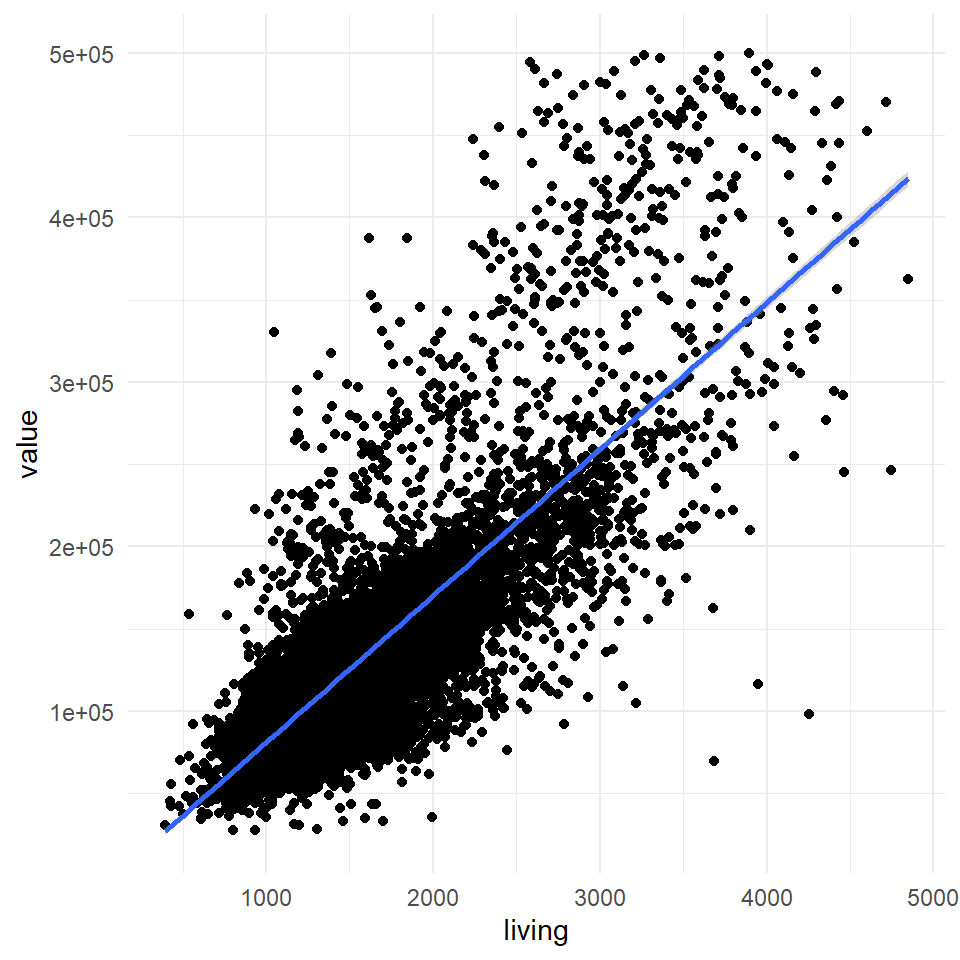

```r
ggplot(data=d, aes(x=living, y=value))+
  geom_point()+
  geom_smooth(method='lm')+
  theme_minimal()
```

Let’s make a similar plot with the `mtcars` data where the gray bands are more visible.

```r
head(mtcars)
```

```
                   mpg cyl disp  hp drat    wt  qsec vs am gear carb
Mazda RX4         21.0   6  160 110 3.90 2.620 16.46  0  1    4    4
Mazda RX4 Wag     21.0   6  160 110 3.90 2.875 17.02  0  1    4    4
Datsun 710        22.8   4  108  93 3.85 2.320 18.61  1  1    4    1
Hornet 4 Drive    21.4   6  258 110 3.08 3.215 19.44  1  0    3    1
Hornet Sportabout 18.7   8  360 175 3.15 3.440 17.02  0  0    3    2
Valiant           18.1   6  225 105 2.76 3.460 20.22  1  0    3    1
```

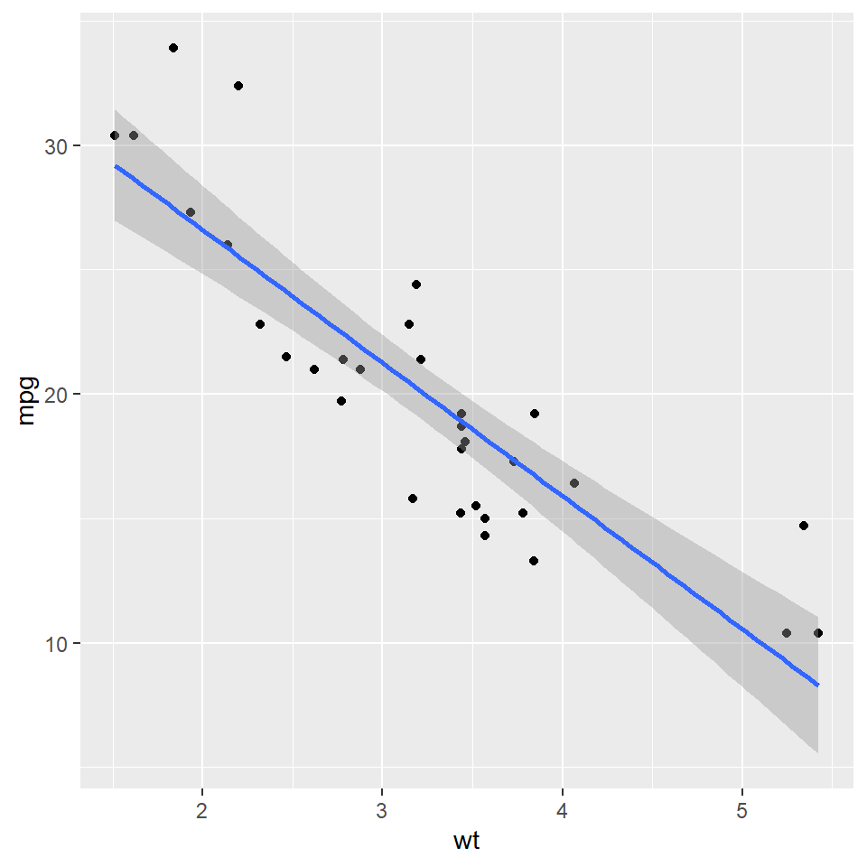

```r
ggplot(mtcars, aes(x=wt, y=mpg))+
  geom_point()+
  geom_smooth(method='lm')
```

## Prediction intervals for $y$

We emphasize the standard errors and confidence intervals suggest that given a value of $x$, the true *mean* value of $y$ is pretty close to our estimate $\hat{y}$. In other words, we are pretty sure about the height of our regression line at that particular $x$. The gray bands in the figure above are the possible heights that the blue line could most likely be.

But we are not saying that all values of $y$ will be close to $\hat{y}$. Those could be spread out above and below the mean. The blue line is what we expect the average to be over lots and lots of individual values of $y$’s.

If we would like to get an idea of an expected range for the individual values of $y$ for a given $x$, we can find the 95% *prediction interval*. With similar reasoning as above, we can get a PI for a future $Y$ observation using
$$\hat y \pm t^*_{n-2} \sqrt{s^2 + s^2_{\hat Y}}$$

```r
yhat - t*sqrt(s^2+sy^2) ## same t as above
```

```
[1] 37301.36
```

```r
yhat + t*sqrt(s^2+sy^2)
```

```
[1] 209426.3
```

We can use the `predict` function to get PIs for all of our $y$’s at once.

```r
d$y.lower = predict(m1, newdata=d, interval='prediction', level=.95)[,'lwr']
d$y.upper = predict(m1, newdata=d, interval='prediction', level=.95)[,'upr']
head(d)
```

```
  pid          address  value year land living    style         grade beds
1   3 199 SOUTH END RD 145670 1950 0.25   1475 Cape Cod Above Average    3
2   4      11 URIAH ST 150710 1989 0.18   1792 Colonial       Average    3
3   5 181 SOUTH END RD 115010 1945 0.36    864    Ranch       Average    3
4   6 169 SOUTH END RD 105280 1940 0.32   1040 Bungalow       Average    3
5   7 173 SOUTH END RD 129290 1986 0.35   1512 Cape Cod       Average    5
6   8 165 SOUTH END RD  95060 1940 0.17   1080 Cape Cod       Average    3
  baths heatfuel  heattype  ac      yhat  yhat.se yhat.lower yhat.upper
1   2.5  Gas/Oil Hot Water  no 123363.84 477.5204  122427.79  124299.89
2   2.5  Gas/Oil Hot Water yes 151615.19 482.0929  150670.18  152560.20
3   1.0  Gas/Oil  FA/HW/ST  no  68910.92 725.9759   67487.84   70334.00
4   1.0  Gas/Oil     Steam  no  84596.21 631.9752   83357.40   85835.03
5   2.0  Gas/Oil  FA/HW/ST yes 126661.32 472.1440  125735.80  127586.83
6   1.5  Gas/Oil  FA/HW/ST  no  88161.05 612.4270   86960.56   89361.55
     y.lower  y.upper
1  37301.365 209426.3
2  65552.616 237677.8
3 -17158.227 154980.1
4  -1470.086 170662.5
5  40598.955 212723.7
6   2095.296 174226.8
```

The interpretation of a prediction interval is that we can expect the prediction interval to contain the observed values of $y$ 95% percent of the time. Notice that the prediction intervals are **much** wider than the confidence intervals. This means that we are much more sure about the *mean* value of $y_j$s than any individual value of $y_j$.

In the figure above, we can think of the prediction interval as being the estimated vertical spread of the points that we would expect for a particular $x$. We plot lines for the prediction interval in red below.

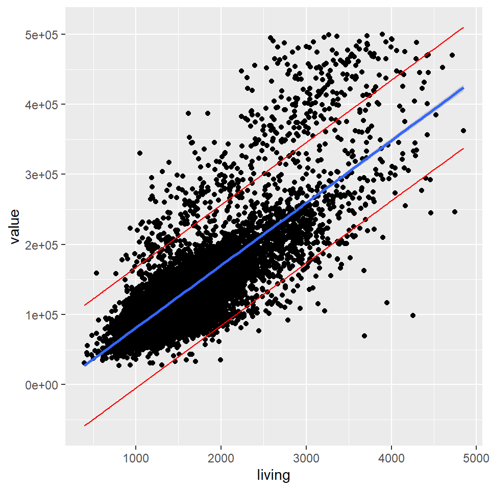

```r
ggplot(data=d, aes(x=living, y=value))+
  geom_point()+
  geom_smooth(method='lm')+
  geom_line(aes(x=living, y=y.lower), color='red')+
  geom_line(aes(x=living, y=y.upper), color='red')
```

It appears as though roughly 95% of the points are between the red lines for smaller living areas. For higher living areas, the prediction interval (and the regression line itself) don’t appear to be great. We’ll return to that soon.

If we’d like, we can count the points in that are below the upper red line, and above the lower red line like this:

```r
pts.inside = length(which(d$value >= d$y.lower &
                            d$value <= d$y.upper))
total.points = nrow(d)
pts.inside/total.points
```

```
[1] 0.9383285
```

We found that 94% of the points are inside the red lines, which is pretty close to 95%.